# Hypothesis 1 — Supervisor briefing

NS-IBTS Q1 (1985–2015) · EEoS haul-level biomass

2026-06-15

Briefing pack for supervisor discussion. Pipeline outputs refreshed on **2026-06-15**; analysis uses frozen data (no dataset updates). See `pipeline/README.md` for run order.

# Part A — Methods (notes)

## A1. Data and analysis sample

- **Survey:** NS-IBTS Quarter 1, 1985–2015
- **Observed biomass (`B_obs`):** FishGlob `sum(wgt) × 1000` → grams per haul (`pipeline/build_eeos_predictions.R`)
- **State variables (S, N, E):** DATRAS HL length bins + FishBase LW lookup (`pipeline/build_datras_state_variables.R`)
- **Join:** Inner join FishGlob ↔︎ DATRAS on 6-field haul key (Survey, Year, Quarter, Country, Ship, HaulNo)
- **Analysis panel:** **12,069** hauls — 12117 joined → 48 excluded by EEoS filters → 12069 with predictions
- **Filter exclusions:** `B_obs > 0`, `S ≥ 2`, `E > N`, finite normalised E (44 zero-biomass FishGlob hauls, mostly 1991; 4 single-species hauls)
- **LW gaps:** Individuals in bins without usable FishBase a/b parameters are dropped from S, N, E (32 MISSING-fallback taxa in lookup; not imputed)

## A2. E calculation — key decisions

| Step | Decision |
| --- | --- |
| Taxa | Fish only; cephalopods, crustaceans, bivalves excluded by AphiaID (`pipeline/R/datras_constants.R`) |
| Length units | LngtCode → cm midpoints (codes 0, 1, 5, `.`) (`pipeline/R/datras_hl_helpers.R`) |
| Mass | W(g) = a·L(cm)^b from frozen `outputs/fishbase_lw_lookup_v2.csv` (TL-type hierarchy, built offline) |
| LW gaps | Bins with missing/non-finite a/b or mass **dropped** before aggregation |
| N | `sum(HLNoAtLngt × SubFactor)` over LW-valid bins (same rows as E) |
| S | `n_distinct(AphiaID)` over same bins (= `n_species_with_lw`) |
| E_raw | `sum(N_at_bin × mass^0.75)` |
| m_min | Mass of **smallest length bin** in haul (not species mean length) |
| E (EEoS input) | `E = E_raw / m_min^0.75` so minimum individual metabolic rate = 1 |

## A3. EEoS prediction at haul level

- Per haul: **S, N, E** (normalised) → Python `biomass.biomass()` via reticulate (`equation_of_state/biomass.py`)
- Output: dimensionless `B_pred_norm`; **`B_pred = B_pred_norm × m_min`** (grams)
- Primary residual: **`log(B_obs) − log(B_pred)`** (negative ⇒ EEoS overpredicts catch biomass)
- Primary R²: **`log_r2()`** = 1 − SS_res/SS_tot (can be negative); **not** cor(log B)²

## A4. Correlative benchmark and null model

**ln(E) reference (Harte et al. 2022):**

- `lm(log(B_obs) ~ log(E))` on same hauls, same normalised E as EEoS (`pipeline/run_h1_lne_reference.R`)
- Harte criterion: EEoS unexplained SS should be **< ½** ln(E) SS

**B-only null (S/N/E not shuffled — breaks EEoS constraints):**

- Fixed `B_pred` from observed (S, N, E); randomise **`B_obs`** only (`pipeline/run_h1_null_model.R`)
- **log(B_obs) is concentrated (IQR/range = 0.12, peak ratio = 4.96, excess kurtosis = 1.02). Empirical resampling would largely recreate the observed biomass scale; primary null uses a uniform draw on the central 95% of log(B_obs).**
- **Primary null:** uniform on central 95% of log(B_obs) (`uniform_log_b_95`; 999 permutations, seed 42)
- **Robustness null:** permute observed B_obs across hauls (`b_shuffle`)

# Part B — Results

## Key numbers

H1 summary statistics

| Quantity | Value |
| --- | --- |
| Analysis hauls (n) | 12,069 |
| Year range | 1985–2015 |
| Median B_obs (g) | 146,873 |
| Median B_pred (g) | 556,490 |
| Median B_pred / B_obs | 4.08 |
| EEoS log_r2 | -0.223 |
| ln(E) log_r2 | 0.595 |
| SS_res ratio (EEoS / ln(E)) | 3.02× |
| Harte criterion met? | No |
| cor(log B)² (diagnostic only) | 0.926 |
| Primary null p (one-sided) | <0.001 |
| Robustness null p (one-sided) | <0.001 |
| Median &#124;residual&#124; EEoS | 1.407 |
| Median &#124;residual&#124; ln(E) | 0.551 |

## Figure 1 — Headline (H1 performance + Harte comparison)

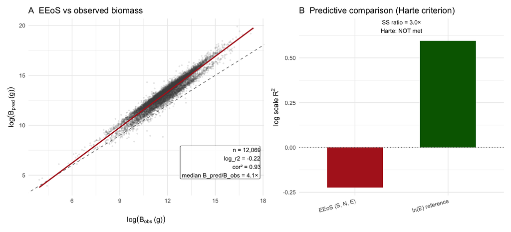

Figure 1. Panel A: observed vs EEoS predicted biomass (log scale). Panel B: log-scale predictive comparison (EEoS vs ln(E) reference).

## Figure 2 — Null model (is any structure real?)

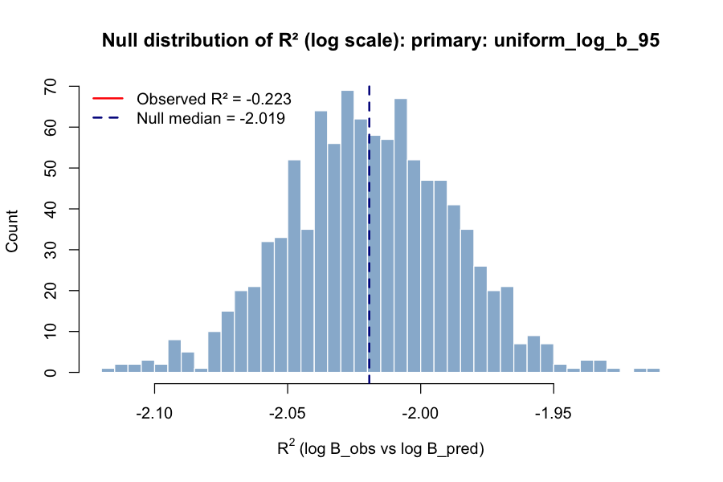

Figure 2. Primary null: distribution of log-scale R² under uniform B_obs randomisation (999 permutations). Red line = observed.

Null-model comparison (B_pred fixed from observed S, N, E)

|  | Role | Scheme | Observed log_r2 | Null median log_r2 | Null 95% interval | p (one-sided) |
| --- | --- | --- | --- | --- | --- | --- |
| 2.5%…1 | Primary | Uniform on 95% log(B) | -0.223 | -2.019 | [-2.079, -1.959] | <0.001 |
| 2.5%…2 | Robustness | B shuffle | -0.223 | -2.598 | [-2.641, -2.556] | <0.001 |

## Supplementary — sample and coverage

### Sample funnel

Haul counts at each pipeline stage

| Stage | N hauls |
| --- | --- |
| DATRAS hauls with valid state (Q1 1985–2015) | 12389 |
| FishGlob ↔︎ DATRAS joined | 12117 |
| Excluded by EEoS filters | 48 |
| EEoS predictions (analysis panel) | 12069 |

### Hauls by year

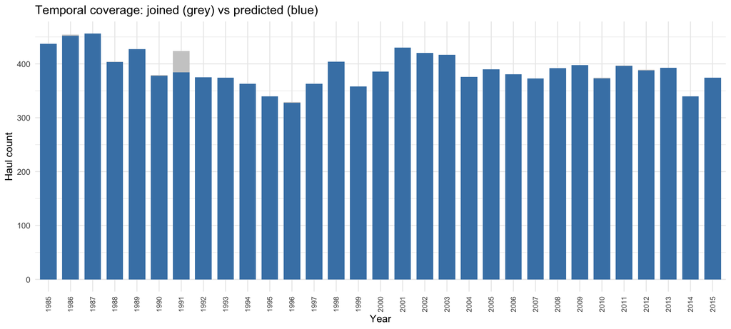

Analysis hauls by year (joined vs predicted). Dropout concentrated in 1991 (zero FishGlob biomass).

### State variable ranges

State variable ranges on analysis panel

| Variable | Min | Median | Max |
| --- | --- | --- | --- |
| S | 2.000 | 13.000 | 33.000 |
| log(N) | 1.099 | 8.406 | 14.234 |
| log(E) | 2.568 | 10.644 | 18.778 |
| log(B_obs) | 3.936 | 11.897 | 17.392 |
| m_min (g) | 0.001 | 2.430 | 428.465 |

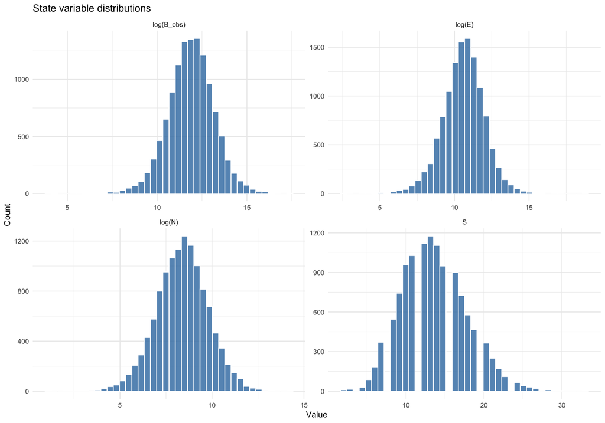

Distributions of state variables and observed biomass.

### log(B_obs) shape and null bounds

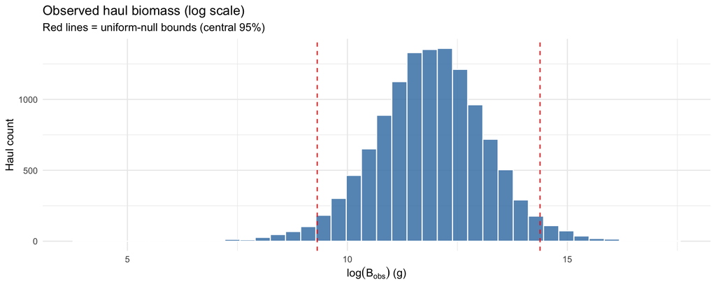

Peaked log(B_obs) distribution with 2.5% and 97.5% quantiles (primary null bounds).

### Residual distributions

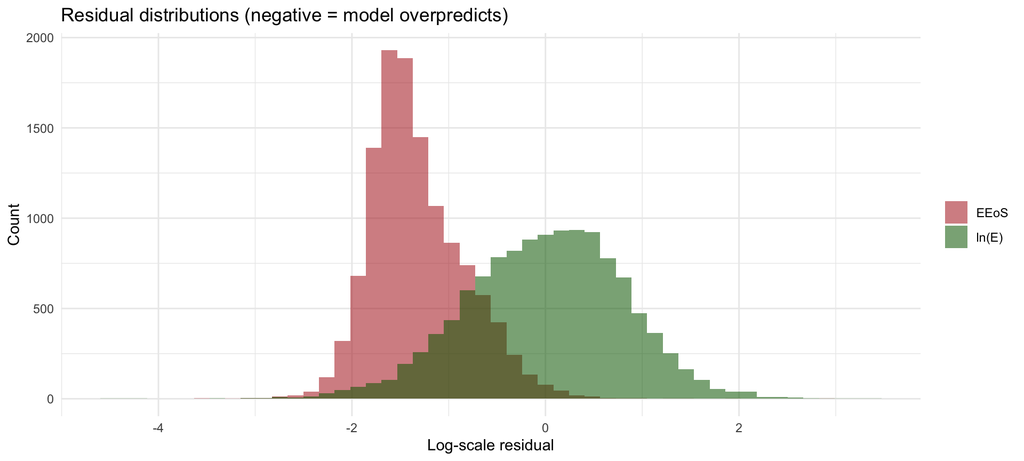

Log-scale residual distributions: EEoS vs ln(E) reference.

### B_pred/B_obs vs community size

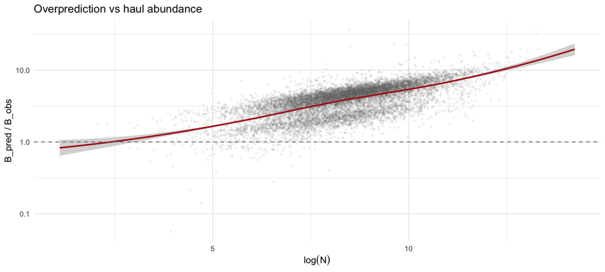

### Metric clarification (log_r2 vs cor²)

Why cor² ≠ predictive success

| Metric | Value | Interpretation |
| --- | --- | --- |
| log_r2 (primary H1) | -0.223 | Predictive: 1 − SS_res/SS_tot; negative = worse than mean |
| cor(log B)² (association only) | 0.926 | Rank association only; can be high despite poor prediction |

### Spatial summary (ICES StatRec)

ICES rectangles with strongest scale offset (n ≥ 5 hauls)

| Group | StatRec | n hauls | Median B_pred/B_obs | Median residual |
| --- | --- | --- | --- | --- |
| Highest B_pred/B_obs | 40G2 | 8 | 7.98 | -2.07 |
| Highest B_pred/B_obs | 43G2 | 52 | 7.69 | -2.04 |
| Highest B_pred/B_obs | 41G2 | 61 | 6.36 | -1.85 |
| Highest B_pred/B_obs | 46G1 | 6 | 6.13 | -1.81 |
| Highest B_pred/B_obs | 41G1 | 62 | 6.07 | -1.80 |
| Highest B_pred/B_obs | 41G0 | 26 | 6.01 | -1.79 |
| Highest B_pred/B_obs | 42G2 | 103 | 5.86 | -1.77 |
| Highest B_pred/B_obs | 43G0 | 29 | 5.65 | -1.73 |
| Highest B_pred/B_obs | 47E8 | 62 | 5.63 | -1.73 |
| Highest B_pred/B_obs | 46E8 | 68 | 5.44 | -1.69 |
| Lowest B_pred/B_obs | 31F3 | 5 | 0.87 | 0.14 |
| Lowest B_pred/B_obs | 40F4 | 79 | 2.27 | -0.82 |
| Lowest B_pred/B_obs | 34F1 | 48 | 2.29 | -0.83 |
| Lowest B_pred/B_obs | 33F1 | 62 | 2.39 | -0.87 |
| Lowest B_pred/B_obs | 32F3 | 48 | 2.43 | -0.89 |
| Lowest B_pred/B_obs | 42E7 | 48 | 2.53 | -0.93 |
| Lowest B_pred/B_obs | 42F7 | 69 | 2.64 | -0.97 |
| Lowest B_pred/B_obs | 28E9 | 8 | 2.66 | -0.98 |
| Lowest B_pred/B_obs | 33F2 | 72 | 2.79 | -1.02 |
| Lowest B_pred/B_obs | 49E7 | 6 | 2.79 | -1.02 |

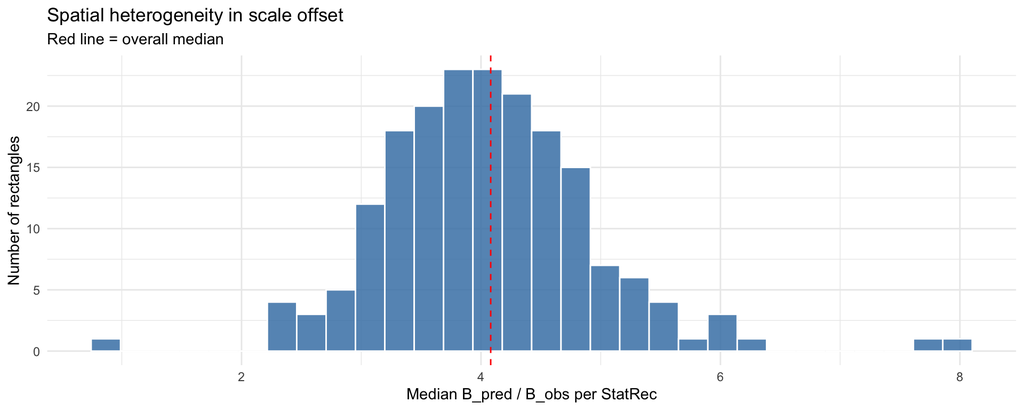

Distribution of median B_pred/B_obs across ICES StatRec rectangles (n ≥ 5 hauls).

*Supervisor-facing briefing — methods and results only. Personal talk track: `review_h1_talk_track.md`. Re-knit after re-running `pipeline/` scripts 1–4.*